# Medicaid Expansion Causal Impact Study

## Overview

This analysis estimates the causal impact of the 2014 Affordable Care Act Medicaid expansion on state-level uninsured rates using a Difference-in-Differences (DiD) design. Data comes from the County Health Rankings (CHR) Trends dataset. The analysis includes an event study to verify the parallel trends assumption, a placebo test, and a robustness check using a tighter pre/post window around 2014.

## Part 1 - Packages

```r
library(readr)
library(dplyr)
library(stringr)
library(fixest)
library(ggplot2)
library(broom)
library(tibble)
```

## Part 2 - Data Import and Outcome Construction

```r
# Loading the CHR Trends dataset
trends <- read_csv("chr_trends_csv_2025.csv", show_col_types = FALSE)

# Extracting state-year uninsured counts and filtering to 2010-2022
unins_cty <- trends %>%
  filter(measurename == "Uninsured") %>%
  mutate(year = as.integer(str_extract(yearspan, "\\d{4}$"))) %>%
  select(statecode, countycode, year, numerator, denominator) %>%
  filter(!is.na(year), year >= 2010, year <= 2022)

# Aggregating county-level counts to state-year uninsured rates
unins_state <- unins_cty %>%
  group_by(statecode, year) %>%
  summarise(
    num = sum(numerator, na.rm = TRUE),
    den = sum(denominator, na.rm = TRUE),
    .groups = "drop"
  ) %>%
  mutate(uninsured_rate = num / den) %>%
  filter(den > 0, !is.na(uninsured_rate))
```

## Part 3 - State FIPS Mapping and Treatment Assignment

```r
# Creating a FIPS-to-state-abbreviation mapping since state.fips is unavailable
fips_to_state <- tibble(
  st_fips = c(
    1,2,4,5,6,8,9,10,11,12,13,15,16,17,18,19,20,21,22,23,
    24,25,26,27,28,29,30,31,32,33,34,35,36,37,38,39,40,41,
    42,44,45,46,47,48,49,50,51,53,54,55,56
  ),
  state = c(
    "AL","AK","AZ","AR","CA","CO","CT","DE","DC","FL","GA","HI","ID","IL","IN","IA","KS","KY","LA","ME",
    "MD","MA","MI","MN","MS","MO","MT","NE","NV","NH","NJ","NM","NY","NC","ND","OH","OK","OR",
    "PA","RI","SC","SD","TN","TX","UT","VT","VA","WA","WV","WI","WY"
  )
)

# Merging state abbreviations into the dataset
dat <- unins_state %>%
  mutate(st_fips = as.integer(statecode)) %>%
  left_join(fips_to_state, by = "st_fips") %>%
  filter(!is.na(state))

# Defining treatment: states that expanded Medicaid by January 1, 2014
# Source: Kaiser Family Foundation (KFF) Medicaid expansion status
expanded_by_2014 <- c(
  "AZ","AR","CA","CO","CT","DE","DC","HI","IL","IA","KY","MD","MA","MN","NV",
  "NJ","NM","NY","ND","OH","OR","RI","VT","WA","WV","MI","NH"
)

dat <- dat %>%
  mutate(
    treated = if_else(state %in% expanded_by_2014, 1L, 0L),
    post    = if_else(year >= 2014, 1L, 0L)
  )

# Sanity checks
table(dat$treated)
```

```
##
##   0   1
## 312 338
```

```r
table(dat$post)
```

```
##
##   0   1
## 200 450
```

```r
table(dat$treated, dat$post)
```

```
##
##       0   1
##   0  96 216
##   1 104 234
```

## Part 4 - Visual Check: Parallel Trends

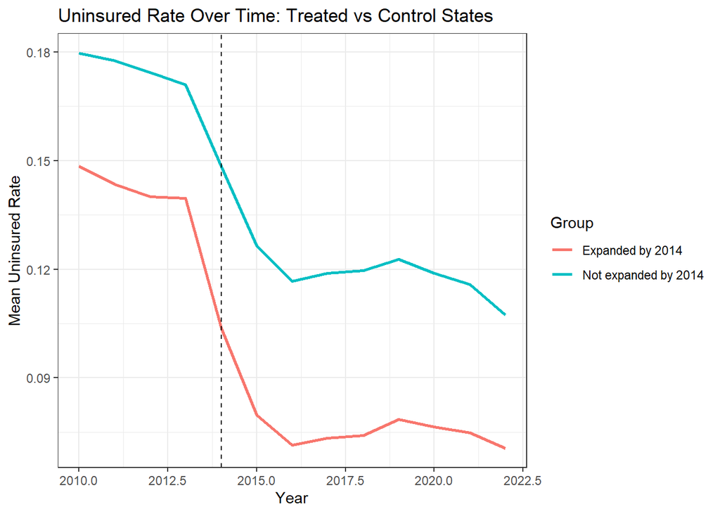

```r
# Plotting mean uninsured rates over time for treated vs control states
# Pre-2014 trends should be parallel if the DiD assumption holds
trend_df <- dat %>%
  group_by(year, treated) %>%
  summarise(mean_unins = mean(uninsured_rate, na.rm = TRUE), .groups = "drop") %>%
  mutate(group = if_else(treated == 1L, "Expanded by 2014", "Not expanded by 2014"))

ggplot(trend_df, aes(x = year, y = mean_unins, color = group)) +
  geom_line(linewidth = 1) +
  geom_vline(xintercept = 2014, linetype = "dashed") +
  labs(
    title = "Uninsured Rate Over Time: Treated vs Control States",
    x     = "Year",
    y     = "Mean Uninsured Rate",
    color = "Group"
  ) +
  theme_bw()
```

## Part 5 - Core DiD Model

```r
# Fitting the DiD model with state and year fixed effects
# Clustering standard errors at the state level to account for within-state correlation
m_did <- feols(
  uninsured_rate ~ treated:post | state + year,
  data    = dat,
  cluster = ~state
)

summary(m_did)
```

```
## OLS estimation, Dep. Var.: uninsured_rate
## Observations: 650
## Fixed-effects: state: 50,  year: 13
## Standard-errors: Clustered (state)
##               Estimate Std. Error  t value Pr(>|t|)
## treated:post -0.010809   0.006386 -1.69264 0.096874 .
## ---
## Signif. codes:  0 '***' 0.001 '**' 0.01 '*' 0.05 '.' 0.1 ' ' 1
## RMSE: 0.011989     Adj. R2: 0.932937
##                  Within R2: 0.041429
```

## Part 6 - Event Study (Parallel Trends Assumption Check)

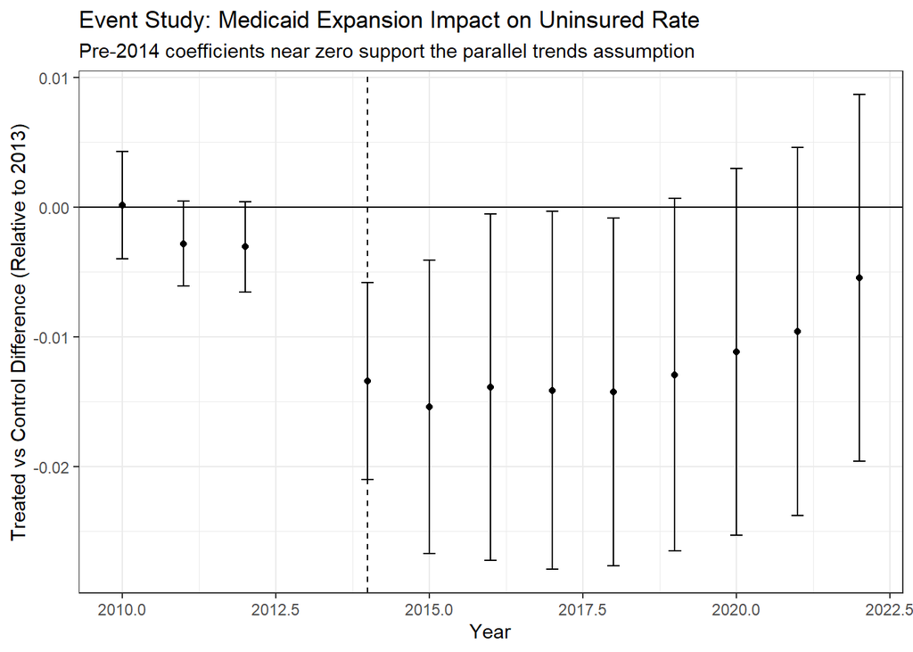

```r
# Fitting an event study model to formally test pre-treatment parallel trends
# 2013 is used as the reference year
m_es <- feols(
  uninsured_rate ~ i(year, treated, ref = 2013) | state + year,
  data    = dat,
  cluster = ~state
)

# Extracting and plotting event study coefficients with confidence intervals
es <- broom::tidy(m_es, conf.int = TRUE) %>%
  filter(grepl("^year::", term)) %>%
  mutate(year = as.integer(str_extract(term, "\\d{4}")))

ggplot(es, aes(x = year, y = estimate)) +
  geom_hline(yintercept = 0) +
  geom_vline(xintercept = 2014, linetype = "dashed") +
  geom_point() +
  geom_errorbar(aes(ymin = conf.low, ymax = conf.high), width = 0.2) +
  labs(
    title = "Event Study: Medicaid Expansion Impact on Uninsured Rate",
    subtitle = "Pre-2014 coefficients near zero support the parallel trends assumption",
    x = "Year",
    y = "Treated vs Control Difference (Relative to 2013)"
  ) +
  theme_bw()
```

## Part 7 - Placebo Test

```r
# Placebo test: assigning a fake policy date of 2012 to check for spurious effects
# A significant result here would undermine the causal interpretation
dat <- dat %>% mutate(post_placebo = if_else(year >= 2012, 1L, 0L))

m_placebo <- feols(
  uninsured_rate ~ treated:post_placebo | state + year,
  data    = dat,
  cluster = ~state
)

summary(m_placebo)
```

```
## OLS estimation, Dep. Var.: uninsured_rate
## Observations: 650
## Fixed-effects: state: 50,  year: 13
## Standard-errors: Clustered (state)
##                       Estimate Std. Error  t value Pr(>|t|)
## treated:post_placebo -0.008956   0.005439 -1.64682  0.10599
## ---
## Signif. codes:  0 '***' 0.001 '**' 0.01 '*' 0.05 '.' 0.1 ' ' 1
## RMSE: 0.012138     Adj. R2: 0.931255
##                  Within R2: 0.017382
```

## Part 8 - Robustness Check

```r
# Restricting to a tighter 2011-2017 window around the 2014 expansion
# to reduce contamination from later policy changes
dat_robust <- dat %>% filter(year >= 2011, year <= 2017)

m_did_robust <- feols(
  uninsured_rate ~ treated:post | state + year,
  data    = dat_robust,
  cluster = ~state
)

summary(m_did_robust)
```

```
## OLS estimation, Dep. Var.: uninsured_rate
## Observations: 350
## Fixed-effects: state: 50,  year: 7
## Standard-errors: Clustered (state)
##               Estimate Std. Error  t value Pr(>|t|)
## treated:post -0.012251   0.005785 -2.11776 0.039293 *
## ---
## Signif. codes:  0 '***' 0.001 '**' 0.01 '*' 0.05 '.' 0.1 ' ' 1
## RMSE: 0.011353     Adj. R2: 0.937385
##                  Within R2: 0.066452
```

## Summary

This analysis used a Difference-in-Differences design to estimate the causal effect of the 2014 Medicaid expansion on state-level uninsured rates. The core DiD model estimated approximately a 1.1 percentage point reduction in uninsured rates among expansion states relative to non-expansion states. The event study confirmed that pre-2014 trends were parallel between treated and control states, supporting the key identifying assumption. The placebo test using a fake 2012 policy date showed no significant effect, and the robustness check using a tighter 2011-2017 window produced a slightly stronger estimate of approximately 1.2 percentage points, consistent with the main result.